# カテゴリカルデータを操作する

カテゴリカルデータとは質的データや定性的データとも呼ばれ、名義尺度または順序尺度の離散的なデータのことです。データを層別するような場合には大変便利なデータで、[R](https://www.r-project.org/)では因子型変数として扱うことができます。しかし、因子型変数は他の変数とは異なり水準（`levels`）という属性を持っているために操作が少々厄介な面もあります。本ページでは、そのようなカテゴリカルデータの扱い方を説明します。

なお、本ページではR version 3.4.4 (2018-03-15)の標準パッケージ以外に以下の追加パッケージを用いています。

| Package | Version | Description |
| --- | --- | --- |
| tidyverse | 1.2.1 | A sample of categorical variables from the General Social survey |
| skimr | 1.0.3 | Compact and Flexible Summaries of Data |
| summarytools | 0.8.7 | Tools to Quickly and Neatly Summarize Data |

また、本ページでは以下のデータセットを用いています。

| Dataset | Package | Version | Description |
| --- | --- | --- | --- |
| gss_cat | forcats | 0.3.0 | A sample of categorical variables from the General Social survey |

| **No** | **Variable** | **Stats / Values** | **Freqs (% of Valid)** | **Graph** | **Valid** | **Missing** |
| --- | --- | --- | --- | --- | --- | --- |
| 1 | year [integer] | mean (sd) : 2006.5 (4.45) min < med < max : 2000 < 2006 < 2014 IQR (CV) : 8 (0) | 2000 : 2817 (13.1%) 2002 : 2765 (12.9%) 2004 : 2812 (13.1%) 2006 : 4510 (21.0%) 2008 : 2023 (9.4%) 2010 : 2044 (9.5%) 2012 : 1974 (9.2%) 2014 : 2538 (11.8%) |  | 21483 (100%) | 0 (0%) |
| 2 | marital [factor] | 1. No answer 2. Never married 3. Separated 4. Divorced 5. Widowed 6. Married | 17 (0.1%) 5416 (25.2%) 743 (3.5%) 3383 (15.8%) 1807 (8.4%) 10117 (47.1%) |  | 21483 (100%) | 0 (0%) |
| 3 | age [integer] | mean (sd) : 47.18 (17.29) min < med < max : 18 < 46 < 89 IQR (CV) : 26 (0.37) | 72 distinct values |  | 21407 (99.65%) | 76 (0.35%) |
| 4 | race [factor] | 1. Other 2. Black 3. White 4. Not applicable | 1959 (9.1%) 3129 (14.6%) 16395 (76.3%) 0 (0.0%) |  | 21483 (100%) | 0 (0%) |
| 5 | rincome [factor] | 1. No answer 2. Don't know 3. Refused 4. $25000 or more 5. $20000 - 24999 6. $15000 - 19999 7. $10000 - 14999 8. $8000 to 9999 9. $7000 to 7999 10. $6000 to 6999 [ 6 others ] | 183 (0.8%) 267 (1.2%) 975 (4.5%) 7363 (34.3%) 1283 (6.0%) 1048 (4.9%) 1168 (5.4%) 340 (1.6%) 188 (0.9%) 215 (1.0%) 8453 (39.3%) |  | 21483 (100%) | 0 (0%) |
| 6 | partyid [factor] | 1. No answer 2. Don't know 3. Other party 4. Strong republican 5. Not str republican 6. Ind,near rep 7. Independent 8. Ind,near dem 9. Not str democrat 10. Strong democrat | 154 (0.7%) 1 (0.0%) 393 (1.8%) 2314 (10.8%) 3032 (14.1%) 1791 (8.3%) 4119 (19.2%) 2499 (11.6%) 3690 (17.2%) 3490 (16.2%) |  | 21483 (100%) | 0 (0%) |
| 7 | relig [factor] | 1. No answer 2. Don't know 3. Inter-nondenominational 4. Native american 5. Christian 6. Orthodox-christian 7. Moslem/islam 8. Other eastern 9. Hinduism 10. Buddhism [ 6 others ] | 93 (0.4%) 15 (0.1%) 109 (0.5%) 23 (0.1%) 689 (3.2%) 95 (0.4%) 104 (0.5%) 32 (0.1%) 71 (0.3%) 147 (0.7%) 20105 (93.6%) |  | 21483 (100%) | 0 (0%) |
| 8 | denom [factor] | 1. No answer 2. Don't know 3. No denomination 4. Other 5. Episcopal 6. Presbyterian-dk wh 7. Presbyterian, merged 8. Other presbyterian 9. United pres ch in us 10. Presbyterian c in us [ 20 others ] | 117 (0.5%) 52 (0.2%) 1683 (7.8%) 2534 (11.8%) 397 (1.8%) 244 (1.1%) 67 (0.3%) 47 (0.2%) 110 (0.5%) 104 (0.5%) 16128 (75.1%) |  | 21483 (100%) | 0 (0%) |
| 9 | tvhours [integer] | mean (sd) : 2.98 (2.59) min < med < max : 0 < 2 < 24 IQR (CV) : 3 (0.87) | 24 distinct values |  | 11337 (52.77%) | 10146 (47.23%) |

# 因子型変数の基本

因子型変数を作成するには、名義尺度は`factor`関数、順序尺度は`ordered`関数を用います。因子型変数が作成される場合、作成に使用したデータから自動的にユニークなデータをソートしたものを抽出して水準（levels）として割り当てます。水準（levels）はデータベースにおけるインデックステーブルのようなものだと考えてください。

## 水準

```r
factor(c("E", "A", "A", "C", "D", "0"))
```

```
## [1] E A A C D 0
## Levels: 0 A C D E
```

```r
ordered(c("E", "A", "A", "C", "D", "0"))
```

```
## [1] E A A C D 0
## Levels: 0 < A < C < D < E
```

`ordered`関数ではこのように水準はアルファニューメリック順の順序関係が付与されていることが分かります。

## 因子型変数の扱い

このように因子型変数は作成時にデータを元に自動的に水準が作成されます。ここに水準にないデータを追加しようとした場合、

```r
x <- factor(c("E", "A", "A", "C", "D", "0"))
x[6:7] <- c("F", "E")
x
```

```
## [1] E    A    A    C    D    <NA> E
## Levels: 0 A C D E
```

このように水準にないデータは追加することができません。

# forcatsパッケージ

前述のような場合に便利なのが`forcats`パッケージです。`forcats`パッケージには

- 水準の順番を変える
- 水準の値を変える
- 新たな水準を追加する
- ヘルパー関数群

などの関数が多数用意されています。

## 水準の順番を変える

`forcats::gss_cat`データセットの`rincome`(reported income)は因子型変数ですが、その水準は以下のようになっています。

```r
forcats::gss_cat$rincome %>%
  levels()
```

```
##  [1] "No answer"      "Don't know"     "Refused"        "$25000 or more"
##  [5] "$20000 - 24999" "$15000 - 19999" "$10000 - 14999" "$8000 to 9999"
##  [9] "$7000 to 7999"  "$6000 to 6999"  "$5000 to 5999"  "$4000 to 4999"
## [13] "$3000 to 3999"  "$1000 to 2999"  "Lt $1000"       "Not applicable"
```

これを逆にして収入の低い順から並べかえ、金額以外の回答を最後に並べるには`forcats::fct_rev`関数と`forcats::fct_relevel`関数を用います。

```r
x <- forcats::gss_cat

(x$rincome <- x$rincome %>%
  forcats::fct_rev() %>%
  forcats::fct_relevel("Don't know", "Not applicable", "Refused", "No answer",
                       after = Inf)) %>%
  levels()
```

```
##  [1] "Lt $1000"       "$1000 to 2999"  "$3000 to 3999"  "$4000 to 4999"
##  [5] "$5000 to 5999"  "$6000 to 6999"  "$7000 to 7999"  "$8000 to 9999"
##  [9] "$10000 - 14999" "$15000 - 19999" "$20000 - 24999" "$25000 or more"
## [13] "Don't know"     "Not applicable" "Refused"        "No answer"
```

本当に水準（`levels`）が変更されているか層別グラフを描いて確認してみます。

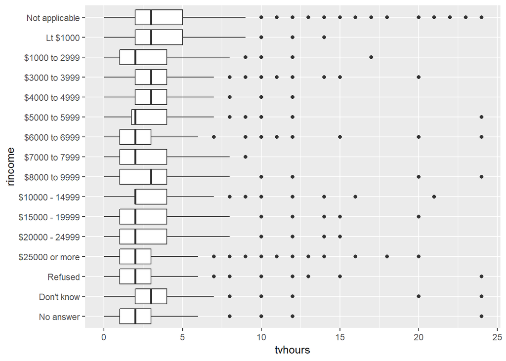

```r
forcats::gss_cat %>%
  ggplot2::ggplot(ggplot2::aes(x = rincome, y = tvhours)) +
    ggplot2::geom_boxplot() +
    ggplot2::coord_flip()
```

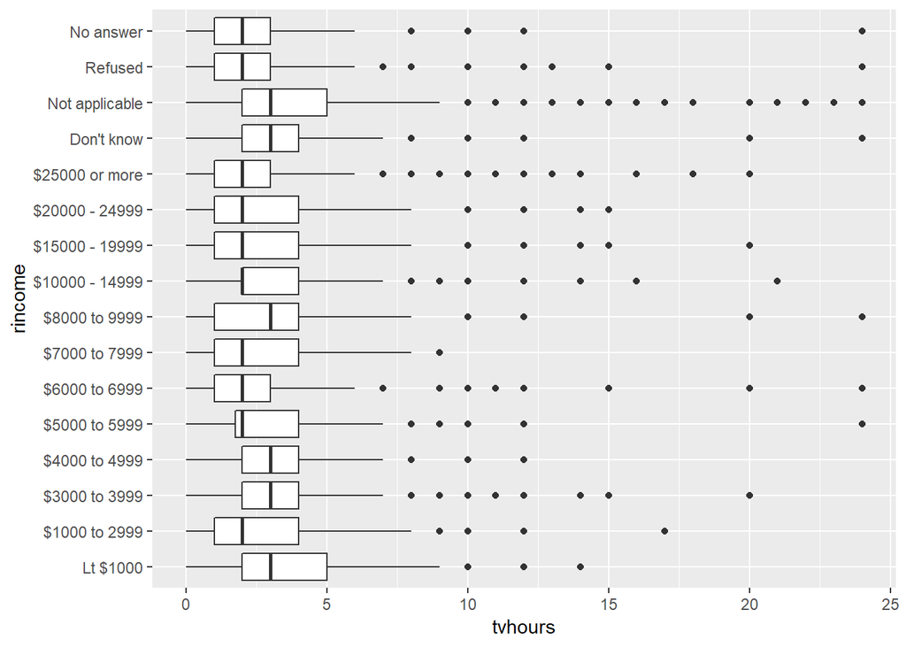

```r
x %>%
  ggplot2::ggplot(ggplot2::aes(x = rincome, y = tvhours)) +
    ggplot2::geom_boxplot() +
    ggplot2::coord_flip()
```

このように収入の低い順から高い順に並べ替えられているのが確認できます。

## 水準の値を変える

`forcats::gss_cat$rincome`の水準は$10,000を境に区切り幅が異なっています。これを均等な区切り幅（$5,000）に統一し、未回答などをまとめてみます。水準をまとめるには`forcats::fct_collapse`関数を用います。

```r
(x$rincome <- x$rincome %>%
  forcats::fct_collapse(
    `to $4999` = c("Lt $1000", "$1000 to 2999", "$3000 to 3999","$4000 to 4999"),
    `$5000 to 9999` = c("$5000 to 5999", "$6000 to 6999", "$7000 to 7999",
                        "$8000 to 9999"),
    missing = c("Don't know", "Not applicable", "No answer")
  )) %>% levels()
```

```
## [1] "to $4999"       "$5000 to 9999"  "$10000 - 14999" "$15000 - 19999"
## [5] "$20000 - 24999" "$25000 or more" "missing"        "Refused"
```

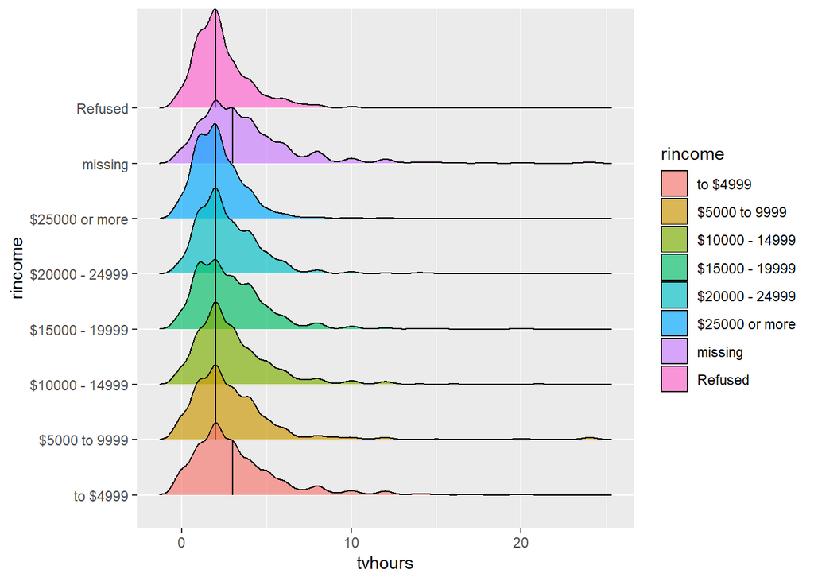

```r
x %>%
  tidyr::drop_na(tvhours) %>%
  # ggplot2::ggplot(ggplot2::aes(x = rincome, y = tvhours)) +
    # ggplot2::geom_boxplot() +
    # ggplot2::coord_flip()
  ggplot2::ggplot(ggplot2::aes(x = tvhours, y = rincome, fill = rincome)) +
    # ggridges::geom_density_ridges_gradient(alpha = 0.65)
    # ggridges::geom_density_ridges(alpha = 0.65)
    ggridges::stat_density_ridges(quantile_lines = TRUE, quantiles = 2,
                                  alpha = 0.65)
```

## 新たな水準を追加する

[Base R](https://www.r-project.org/)で水準を追加する場合には`levels`関数を用いて以下のように行います。

```r
x <- factor(c("E", "A", "A", "C", "D", "0"))
x
```

```
## [1] E A A C D 0
## Levels: 0 A C D E
```

```r
levels(x)[6] <- "F"
x
```

```
## [1] E A A C D 0
## Levels: 0 A C D E F
```

このように`levels`関数では、指定した位置に水準を追加するため指定位置を間違えるとデータの値も入れ替わってしまいます。

```r
x <- factor(c("E", "A", "A", "C", "D", "0"))
x
```

```
## [1] E A A C D 0
## Levels: 0 A C D E
```

```r
levels(x)[5] <- "G"
x
```

```
## [1] G A A C D 0
## Levels: 0 A C D G
```

`forcats`パッケージを利用すると位置を指定する必要がなく指定間違いよりデータの値が入れ替わってしまうリスクもありません。

```r
x <- factor(c("E", "A", "A", "C", "D", "0"))
x
```

```
## [1] E A A C D 0
## Levels: 0 A C D E
```

```r
x <- forcats::fct_expand(x, c("G", "F"))
x
```

```
## [1] E A A C D 0
## Levels: 0 A C D E G F
```

```r
x[6:7] <- c("F", "E")
x
```

```
## [1] E A A C D F E
## Levels: 0 A C D E G F
```

## 水準を並べ替える

```r
# 手動で並べ替える
x
```

```
## [1] E A A C D F E
## Levels: 0 A C D E G F
```

```r
forcats::fct_relevel(x, "G", after = 7)
```

```
## [1] E A A C D F E
## Levels: 0 A C D E F G
```

```r
# 出現順に並べ替える
f <- forcats::factor(c("b", "b", "a", "c", "c", "c"))
```

```
## Error: 'factor' is not an exported object from 'namespace:forcats'
```

```r
f
```

```
## Error in eval(expr, envir, enclos):  オブジェクト 'f' がありません
```

```r
forcats::fct_inorder(f)
```

```
## Error in check_factor(f):  オブジェクト 'f' がありません
```

```r
# レベルにあってもデータにないとエラーになる
x
```

```
## [1] E A A C D F E
## Levels: 0 A C D E G F
```

```r
forcats::fct_inorder(x)
```

```
## Error: `idx` must contain one integer for each level of `f`
```

```r
forcats::fct_inorder(factor(c("E", "A", "A", "C", "D", "0")))
```

```
## [1] E A A C D 0
## Levels: E A C D 0
```

```r
x
```

```
## [1] E A A C D F E
## Levels: 0 A C D E G F
```

```r
as.character(sort(unique(x)))
```

```
## [1] "A" "C" "D" "E" "F"
```

```r
sort(levels(x))
```

```
## [1] "0" "A" "C" "D" "E" "F" "G"
```

```r
diff()
```

```
## Error in diff.default():  引数 "x" がありませんし、省略時既定値もありません
```

```r
x <- ordered(c("E", "A", "A", "C", "D", "0"))
x
```

```
## [1] E A A C D 0
## Levels: 0 < A < C < D < E
```

```r
x <- forcats::fct_expand(x, c("F", "1"))
x[6:7] <- c("F", "E")
x
```

```
## [1] E A A C D F E
## Levels: 0 < A < C < D < E < F < 1
```

このように標準の[R](https://www.r-project.org/)ではカテゴリカルデータの扱いが少々厄介ですが`forcats`パッケージを使用することで、このような厄介な処理を簡単にこなせるようになります。

# カテゴリカルデータを扱う

使用するデータは前述にあるように`forcats`パッケージに包含されている`gss_cat`データセットを用います。`gss_cat`は九つの変数からなるデータセットで、内、六つの変数が`factor`型、すなわちカテゴリカルデータです。データの詳細については`forcats`のヘルプをご覧ください。

```r
forcats::gss_cat %>%
  skimr::skim_to_wide()
```

| type | variable | missing | complete | n | n_unique | top_counts | ordered | mean | sd | p0 | p25 | p50 | p75 | p100 | hist |
| --- | --- | --- | --- | --- | --- | --- | --- | --- | --- | --- | --- | --- | --- | --- | --- |
| factor | denom | 0 | 21483 | 21483 | 30 | Not: 10072, Oth: 2534, No : 1683, Sou: 1536 | FALSE | NA | NA | NA | NA | NA | NA | NA | NA |
| factor | marital | 0 | 21483 | 21483 | 6 | Mar: 10117, Nev: 5416, Div: 3383, Wid: 1807 | FALSE | NA | NA | NA | NA | NA | NA | NA | NA |
| factor | partyid | 0 | 21483 | 21483 | 10 | Ind: 4119, Not: 3690, Str: 3490, Not: 3032 | FALSE | NA | NA | NA | NA | NA | NA | NA | NA |
| factor | race | 0 | 21483 | 21483 | 3 | Whi: 16395, Bla: 3129, Oth: 1959, Not: 0 | FALSE | NA | NA | NA | NA | NA | NA | NA | NA |
| factor | relig | 0 | 21483 | 21483 | 15 | Pro: 10846, Cat: 5124, Non: 3523, Chr: 689 | FALSE | NA | NA | NA | NA | NA | NA | NA | NA |
| factor | rincome | 0 | 21483 | 21483 | 16 | $25: 7363, Not: 7043, $20: 1283, $10: 1168 | FALSE | NA | NA | NA | NA | NA | NA | NA | NA |
| integer | age | 76 | 21407 | 21483 | NA | NA | NA | 47.18 | 17.29 | 18 | 33 | 46 | 59 | 89 |  |
| integer | tvhours | 10146 | 11337 | 21483 | NA | NA | NA | 2.98 | 2.59 | 0 | 1 | 2 | 4 | 24 |  |
| integer | year | 0 | 21483 | 21483 | NA | NA | NA | 2006.5 | 4.45 | 2000 | 2002 | 2006 | 2010 | 2014 |  |

## 因子型変数の水準を確認する

因子型変数の水準を確認するには`levels`関数、`unique`関数または`forcats::fct_unique`関数を用います。`levels`関数と`forcats::fct_unique`関数の動作は等価で水準は水準順に表示されます。一方、`unique`関数は水準の出現順に水準を表示することに注意してください。

```r
forcats::gss_cat$marital %>%
  levels()
```

```
## [1] "No answer"     "Never married" "Separated"     "Divorced"
## [5] "Widowed"       "Married"
```

```r
forcats::gss_cat$marital %>%
  unique()
```

```
## [1] Never married Divorced      Widowed       Married       Separated
## [6] No answer
## Levels: No answer Never married Separated Divorced Widowed Married
```

```r
forcats::gss_cat$marital %>%
  forcats::fct_unique()
```

```
## [1] No answer     Never married Separated     Divorced      Widowed
## [6] Married
## Levels: No answer Never married Separated Divorced Widowed Married
```

# 参考資料

- [公式リファレンス（英語）](https://forcats.tidyverse.org/reference/index.html)
- [{forcats}パッケージでカテゴリカル変数(factor型データ)をいじってみる](https://kazutan.github.io/kazutanR/forcats_test.html)

[CC BY-NC-SA 4.0](http://creativecommons.org/licenses/by-nc-sa/4.0/deed.ja) , Sampo Suzuki [2018-09-20 17:44(JST)]